# EDA Projeto 1 Checkpoint 1

```r
episodios = read_csv(here("data/series_from_imdb.csv"),
                    progress = FALSE,
                    col_types = cols(.default = col_double(),
                                     series_name = col_character(),
                                     episode = col_character(),
                                     url = col_character(),
                                     season = col_character())) %>%
    filter(series_name %in% c("Friends", "How I Met Your Mother"))
```

# Problema:

Escolher entre 2 e 4 séries da base de dados e responder as seguintes questões:

As séries escolhidas foram **How I Met Your Mother** e **Friends**, que são séries do mesmo gênero, com temáticas parecidas e com um numero próximo de temporadas.

### Pergunta 1: Qual das séries que você escolheu é mais bem avaliada no IMDB? A diferença é grande? Pequena? Muda de acordo com as temporadas da série?

Fazendo a média da avaliação de todos os episódios das séries, temos que:

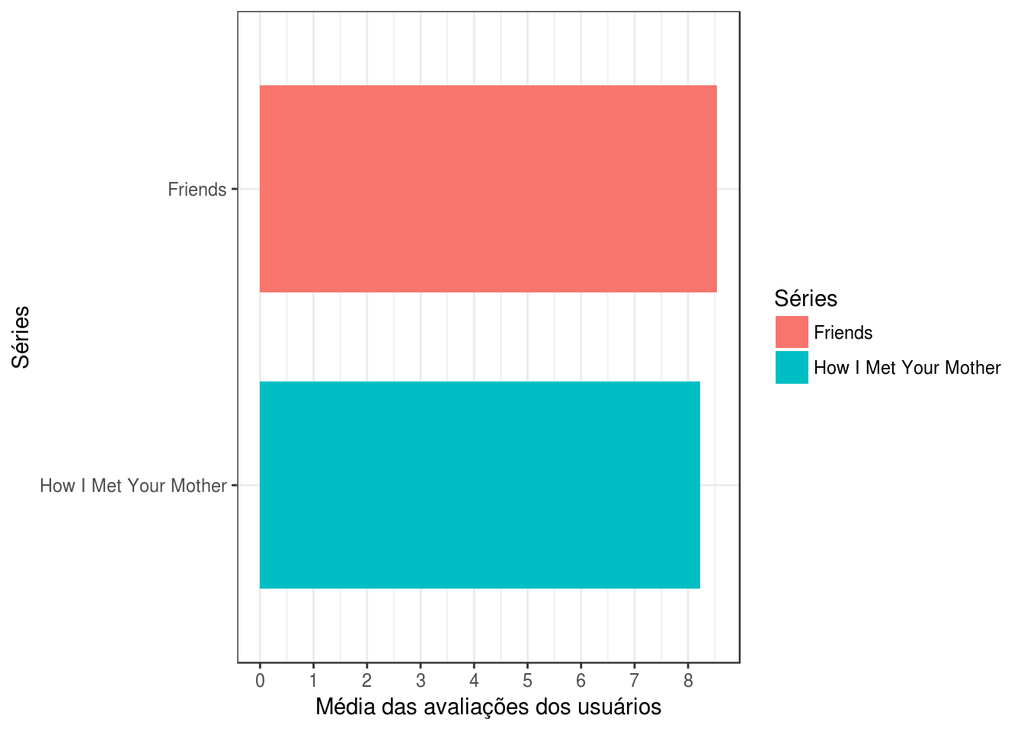

```r
media_episodios =
  episodios %>%
  group_by(series_name) %>%
    summarise(user_rating = mean(user_rating)) %>%
    arrange(desc(user_rating))

media_episodios %>%
  ggplot(aes(x = reorder(series_name, user_rating), y = user_rating, fill = series_name)) +
    geom_col(width = 0.7) +
    scale_y_continuous(breaks=seq(0, 10, 1)) +
    xlab("Séries") + ylab("Média das avaliações dos usuários") +
    coord_flip() + labs(fill = "Séries")
```

Assim, podemos observar que utilizando a média das avaliações de todos os episódios de cada série como critério de comparação entre as séries, podemos observar que **Friends** leva uma pequena vantagens em relação à **How I Met Your Mother**.

Contudo, utilizar a `média` de todos os dados do conjunto como instrumento de medida pode não ser uma boa forma de comparação, uma vez que essa forma de medir os dados é muito sussetível a valores muito discrepantes para um conjunto pequeno de dados.

Visualizando dados de avaliações de usuários individualmente, temos:

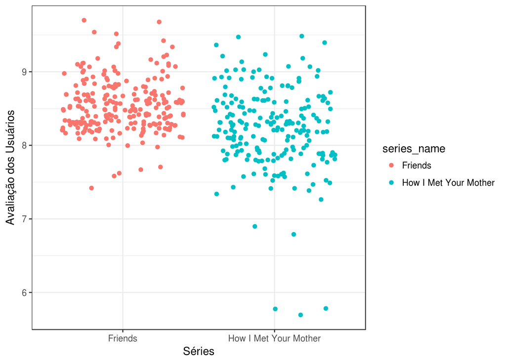

```r
episodios %>%
  ggplot(aes(x = series_name, y = user_rating, col = series_name)) +
    geom_jitter() +
    xlab("Séries") + ylab("Avaliação dos Usuários") + labs(fill = "Séries")
```

Vemos com isso que existem dados discrepantes que interferem na média das avaliações.

Uma forma mais interessante então é avaliar os dados através da `mediana`, que nos dá um valor central no conjunto de dados e não sofre com interferências causadas por grandes discrepâncias nos dados.

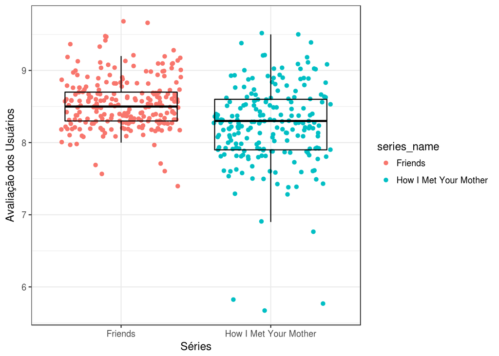

```r
episodios %>%
  ggplot(aes(x = series_name, y = user_rating, col=series_name)) +
    geom_jitter(width = .4) +
    geom_boxplot(color="black", alpha=0) +
    xlab("Séries") + ylab("Avaliação dos Usuários") + labs(fill = "Séries")
```

Ao observarmos os valores das medianas (linha horizontal no meio da “caixa”) vemos que **Friends** ainda continua na frente.

Assim, podemos concluir que, por uma pequena vantagem, **Frieds** é mais bem avaliada que **How I Met Your Mother**.

Vejamos como é o resultado se analisarmos por temporada:

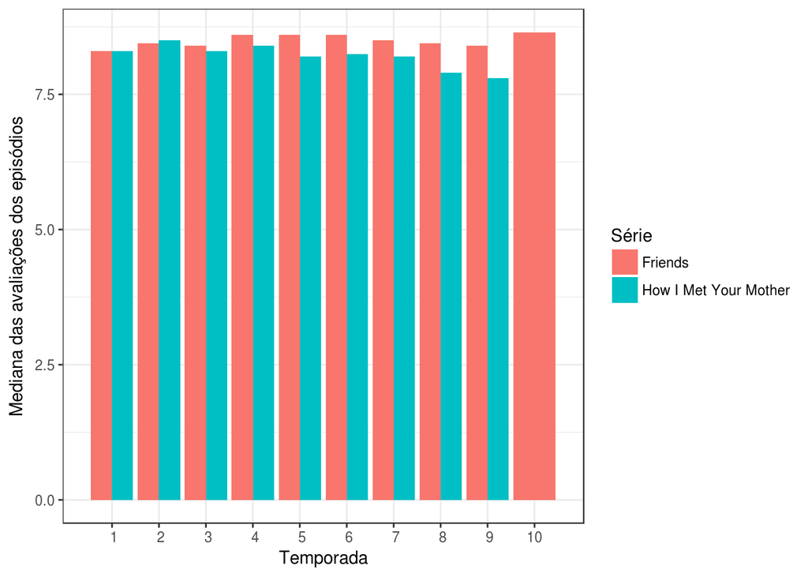

```r
series_por_mediana =
  episodios %>%
  mutate(season = as.integer(season)) %>%
  group_by(series_name, season) %>%
    summarise(user_rating = median(user_rating)) %>%
    arrange(desc(season))

series_por_mediana %>%
ggplot(aes(x=season, y=user_rating, fill=factor(series_name)))+
  geom_bar(stat="identity", position="dodge")+
  scale_fill_discrete(name = "Série") +
  scale_x_discrete(name="Temporada", limits=c(1:10)) +
  ylab("Mediana das avaliações dos episódios")
```

## Pergunta 2: Qual das séries que você escolheu tem episódios de qualidade mais irregular segundo o IMDB? A diferença é grande? Pequena?

Utilizando o mesmo gráfico das medianas das séries, é possível ver a dispersão dos episódios:

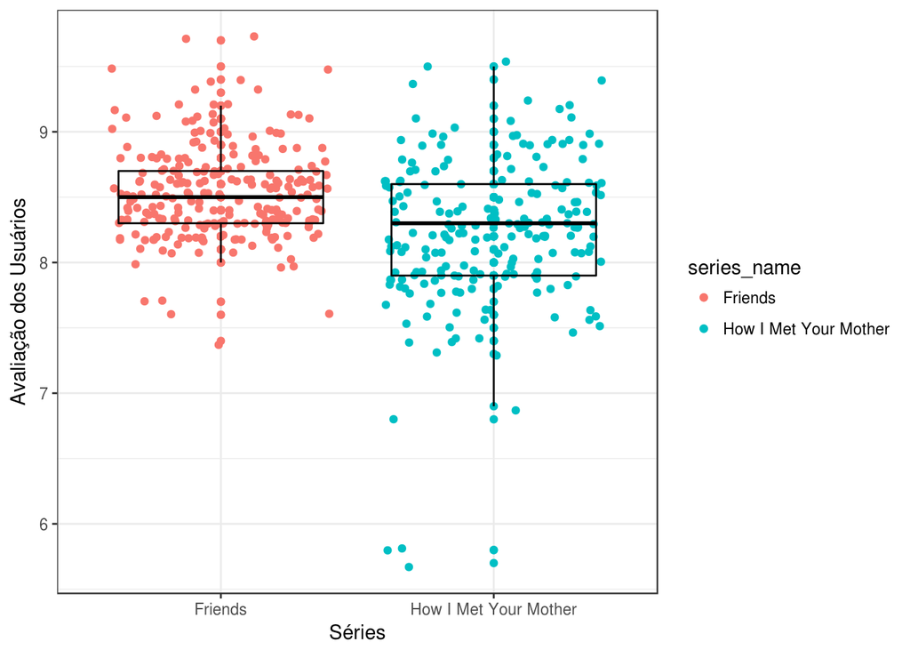

```r
episodios %>%
  ggplot(aes(x = series_name, y = user_rating, col=series_name)) +
    geom_point() +
    geom_jitter(width = .4) +
    geom_boxplot(color="black", alpha=0) +
    xlab("Séries") + ylab("Avaliação dos Usuários") + labs(fill = "Séries")
```

Podemos ver que os votos de **Friends** estão muito mais concentrados em torno da mediana que os de **How I Met Your Mother**, assim, podemos dizer que **How I Met Your Mother** é muito mais irregular.